# Exercise 7 - Nonlinear Models and Tree-based Methods

Ken Benoit, Slava Mikhaylov, and Jack Blumenau

### Exercise 7.1

This question relates to the `College` dataset from the `ISLR` package.

1. Split the data into a training set and a test set. Using out-of-state tuition as the response and the other variables as the predictors, perform appropriate model selection of your choice (from day6) on the training set in order to identify a satisfactory model that uses just a subset of the predictors.

```r
library(ISLR)
library(glmnet)
library(leaps)
```

```r
set.seed(11)
sum(is.na(College))
```

```
## [1] 0
```

```r
train.size <-  nrow(College) / 2
train <-  sample(1:nrow(College), train.size)
test <-  -train
College.train <-  College[train, ]
College.test <-  College[test, ]
train.mat <-  model.matrix(Outstate ~ . , data = College.train)
test.mat <-  model.matrix(Outstate ~ . , data = College.test)
grid <-  10 ^ seq(4, -2, length = 100)
```

```r
mod.lasso <-  cv.glmnet(train.mat, College.train[, "Outstate"], alpha = 1,
                        lambda = grid, thresh = 1e-12)

lambda.best <-  mod.lasso$lambda.min
lambda.best
```

```
## [1] 4.641589
```

```r
lasso <- glmnet(train.mat, College.train[, "Outstate"], alpha = 1, lambda = grid)

lasso.coef <-  predict(lasso, type= "coefficients", s = lambda.best)
lasso.coef
```

```
## 19 x 1 sparse Matrix of class "dgCMatrix"
##                         1
## (Intercept) -2.677473e+03
## (Intercept)  .
## PrivateYes   2.477499e+03
## Apps        -2.058597e-01
## Accept       9.387032e-01
## Enroll      -1.679056e+00
## Top10perc    1.249575e+01
## Top25perc    1.030767e+01
## F.Undergrad -1.445145e-05
## P.Undergrad  4.749193e-02
## Room.Board   6.232943e-01
## Books       -2.245527e-01
## Personal    -7.970472e-02
## PhD          2.364911e+01
## Terminal     5.218150e+00
## S.F.Ratio   -7.363054e+00
## perc.alumni  4.226937e+01
## Expend       3.156459e-01
## Grad.Rate    2.961723e+01
```

```r
set.seed(1)

train <-  sample(1:nrow(College), nrow(College)/2)
test <-  -train
College.train <-  College[train, ]
College.test <-  College[test, ]

reg.fit <-  regsubsets(Outstate~., data=College.train, nvmax=17, method="forward")

reg.summary <-  summary(reg.fit)
```

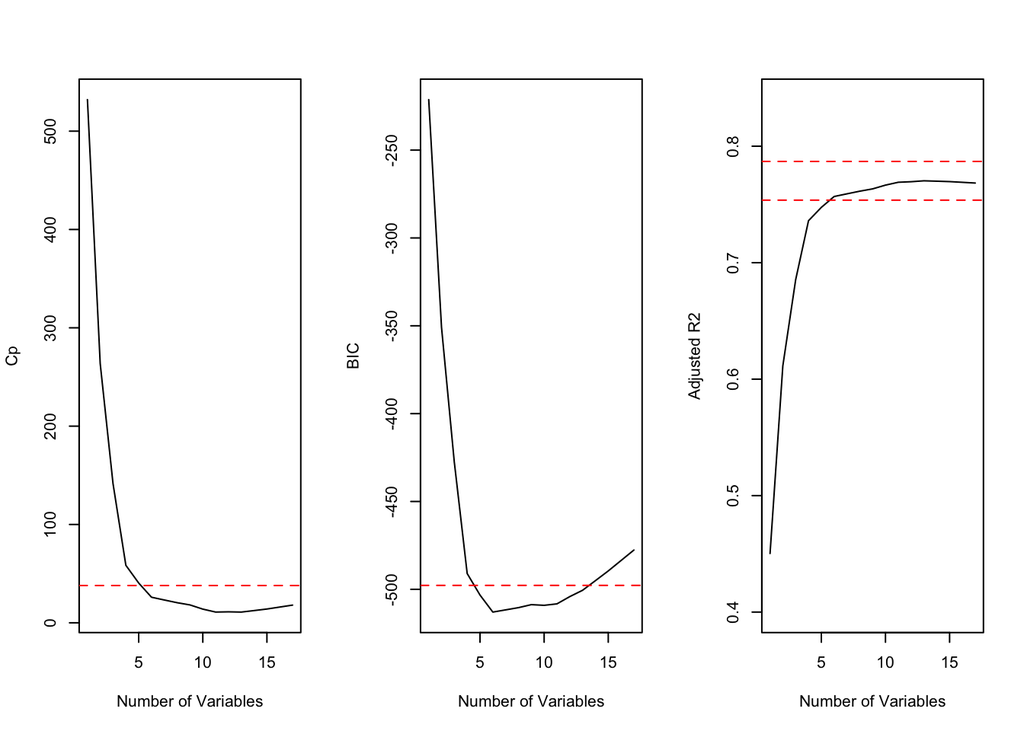

```r
par(mfrow=c(1, 3))
plot(reg.summary$cp,xlab="Number of Variables",ylab="Cp",type='l')
min.cp <-  min(reg.summary$cp)
std.cp <-  sd(reg.summary$cp)
abline(h=min.cp+0.2*std.cp, col="red", lty=2)
abline(h=min.cp-0.2*std.cp, col="red", lty=2)
plot(reg.summary$bic,xlab="Number of Variables",ylab="BIC",type='l')
min.bic <-  min(reg.summary$bic)
std.bic <-  sd(reg.summary$bic)
abline(h=min.bic+0.2*std.bic, col="red", lty=2)
abline(h=min.bic-0.2*std.bic, col="red", lty=2)
plot(reg.summary$adjr2,xlab="Number of Variables",
     ylab="Adjusted R2",type='l', ylim=c(0.4, 0.84))
max.adjr2 <-  max(reg.summary$adjr2)
std.adjr2 <-  sd(reg.summary$adjr2)
abline(h=max.adjr2+0.2*std.adjr2, col="red", lty=2)
abline(h=max.adjr2-0.2*std.adjr2, col="red", lty=2)
```

**BIC scores show 6 as the optimal size. Cp, BIC and adjr2 show that size 6 is the minimum size for the subset for which the scores are withing 0.2 standard deviations of optimum. We pick 6 as the best subset size and find best 6 variables using entire data.**

```r
reg.fit <-  regsubsets(Outstate ~ . , data=College, method="forward")
coefi <-  coef(reg.fit, id=6)
names(coefi)
```

```
## [1] "(Intercept)" "PrivateYes"  "Room.Board"  "PhD"         "perc.alumni"
## [6] "Expend"      "Grad.Rate"
```

2. Fit a GAM on the training data, using out-of-state tuition as the response and the features selected in the previous step as the predictors. Plot the results, and explain your findings.

```r
library(gam)
```

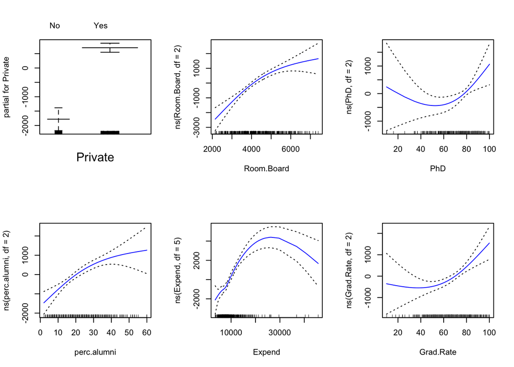

```r
gam.fit <-  gam(Outstate ~ Private + ns(Room.Board, df=2) +
                  ns(PhD, df=2) + ns(perc.alumni, df=2) +
                  ns(Expend, df=5) + ns(Grad.Rate, df=2),
                data=College.train)
par(mfrow=c(2, 3))
plot(gam.fit, se=TRUE, col="blue")
```

** We discussed this type of graphs in the lecture. The fitted natural splines with +/- 2*SE confidence interval. Ticks at the bottom show density of the data (aka `rug plot’).**

3. Evaluate the model obtained on the test set, and explain the results obtained.

```r
gam.pred <-  predict(gam.fit, College.test)
gam.err <-  mean((College.test$Outstate - gam.pred)^2)
gam.err
```

```
## [1] 3960682
```

```r
gam.tss <-  mean((College.test$Outstate - mean(College.test$Outstate))^2)
test.rss <-  1 - gam.err / gam.tss
test.rss
```

```
## [1] 0.7564575
```

4. For which variables, if any, is there evidence of a non-linear relationship with the response?

```r
summary(gam.fit)
```

```
##
## Call: gam(formula = Outstate ~ Private + ns(Room.Board, df = 2) + ns(PhD,
##     df = 2) + ns(perc.alumni, df = 2) + ns(Expend, df = 5) +
##     ns(Grad.Rate, df = 2), data = College.train)
## Deviance Residuals:
##        Min         1Q     Median         3Q        Max
## -4935.9726 -1237.3034     0.9575  1254.0286  7725.8317
##
## (Dispersion Parameter for gaussian family taken to be 3353372)
##
##     Null Deviance: 6221998532 on 387 degrees of freedom
## Residual Deviance: 1250807925 on 373 degrees of freedom
## AIC: 6947.684
##
## Number of Local Scoring Iterations: 2
##
## Anova for Parametric Effects
##                          Df     Sum Sq    Mean Sq  F value    Pr(>F)
## Private                   1 2038688757 2038688757 607.9518 < 2.2e-16 ***
## ns(Room.Board, df = 2)    2 1465963012  732981506 218.5804 < 2.2e-16 ***
## ns(PhD, df = 2)           2  702697677  351348839 104.7748 < 2.2e-16 ***
## ns(perc.alumni, df = 2)   2  354083533  177041767  52.7951 < 2.2e-16 ***
## ns(Expend, df = 5)        5  346840642   69368128  20.6861 < 2.2e-16 ***
## ns(Grad.Rate, df = 2)     2   62916986   31458493   9.3812 0.0001059 ***
## Residuals               373 1250807925    3353372
## ---
## Signif. codes:  0 '***' 0.001 '**' 0.01 '*' 0.05 '.' 0.1 ' ' 1
```

### Exercise 7.2

Apply bagging and random forests to a data set of your choice. Be sure to fit the models on a training set and to evaluate their performance on a test set. How accurate are the results compared to simple methods like linear or logistic regression? Which of these approaches yields the best performance?

**In this exercise we examine the `Weekly` stock market data from the ISLR package.**

```r
set.seed(1)
summary(Weekly)
```

```
##       Year           Lag1               Lag2               Lag3
##  Min.   :1990   Min.   :-18.1950   Min.   :-18.1950   Min.   :-18.1950
##  1st Qu.:1995   1st Qu.: -1.1540   1st Qu.: -1.1540   1st Qu.: -1.1580
##  Median :2000   Median :  0.2410   Median :  0.2410   Median :  0.2410
##  Mean   :2000   Mean   :  0.1506   Mean   :  0.1511   Mean   :  0.1472
##  3rd Qu.:2005   3rd Qu.:  1.4050   3rd Qu.:  1.4090   3rd Qu.:  1.4090
##  Max.   :2010   Max.   : 12.0260   Max.   : 12.0260   Max.   : 12.0260
##       Lag4               Lag5              Volume
##  Min.   :-18.1950   Min.   :-18.1950   Min.   :0.08747
##  1st Qu.: -1.1580   1st Qu.: -1.1660   1st Qu.:0.33202
##  Median :  0.2380   Median :  0.2340   Median :1.00268
##  Mean   :  0.1458   Mean   :  0.1399   Mean   :1.57462
##  3rd Qu.:  1.4090   3rd Qu.:  1.4050   3rd Qu.:2.05373
##  Max.   : 12.0260   Max.   : 12.0260   Max.   :9.32821
##      Today          Direction
##  Min.   :-18.1950   Down:484
##  1st Qu.: -1.1540   Up  :605
##  Median :  0.2410
##  Mean   :  0.1499
##  3rd Qu.:  1.4050
##  Max.   : 12.0260
```

```r
train <-  sample(nrow(Weekly), 2/3 * nrow(Weekly))
test <-  -train
```

**Logistic regression**

```r
glm.fit <-  glm(Direction ~ . -Year-Today,
                data=Weekly[train,],
                family="binomial")

glm.probs <-  predict(glm.fit, newdata=Weekly[test, ],
                      type = "response")
glm.pred <-  rep("Down", length(glm.probs))
glm.pred[glm.probs > 0.5] <-  "Up"
table(glm.pred, Weekly$Direction[test])
```

```
##
## glm.pred Down  Up
##     Down    3   2
##     Up    176 182
```

```r
mean(glm.pred != Weekly$Direction[test])
```

```
## [1] 0.4903581
```

**Bagging**

```r
library(randomForest)
Weekly <-  Weekly[,!(names(Weekly) %in% c("BinomialDirection"))]

bag.weekly <-  randomForest(Direction~.-Year-Today,
                            data=Weekly,
                            subset=train,
                            mtry=6)

yhat.bag <-  predict(bag.weekly, newdata=Weekly[test,])
table(yhat.bag, Weekly$Direction[test])
```

```
##
## yhat.bag Down  Up
##     Down   57  49
##     Up    122 135
```

```r
mean(yhat.bag != Weekly$Direction[test])
```

```
## [1] 0.4710744
```

**Random forests**

```r
rf.weekly <-  randomForest(Direction ~ . -Year-Today,
                           data=Weekly,
                           subset=train,
                           mtry=2)

yhat.bag <-  predict(rf.weekly, newdata=Weekly[test,])
table(yhat.bag, Weekly$Direction[test])
```

```
##
## yhat.bag Down  Up
##     Down   49  46
##     Up    130 138
```

```r
mean(yhat.bag != Weekly$Direction[test])
```

```
## [1] 0.4848485
```

**Best performance summary: Bagging resulted in the lowest validation set test error rate.**